# FinTrust Digital Banking — Week 3: Advanced Predictive Risk Modeling & System Validation

> **Track:** Data Science  
> **Author:** Dorian NJAMI — Certified Data Scientist  
> **Phase:** Week 3 — Model Refinement, Time-Aware Validation & Advanced Ensembles  
> **Project Scope:** FinTrust Financial Intelligence & Digital Banking Support Solution

## Project Overview & Iterative Evolution (Week 2 Refinements + Week 3 Advanced Modeling)

Following the strategic planning established in **Week 1 (Problem Formulation)** and initial technical execution in **Week 2 (Data Preparation, Baseline Modeling & EDA)**, this notebook advances the **FinTrust Digital Banking Risk Review** project into a complete, technically robust, and production-ready predictive solution.

In accordance with mentor evaluation feedback on Week 2, this notebook incorporates **5 critical technical refinements** in data preparation, feature engineering, and validation methodology prior to deploying advanced classification architectures (XGBoost, LightGBM, and tuned Ensembles).

## Key Technical Refinements Implemented (Based on Mentor Feedback)

To eliminate methodological weaknesses and data leakage present in the initial baseline, the following adjustments have been applied:

1. **Data Leakage Elimination in Feature Engineering:** Customer-level historical metrics (e.g., `Customer_Tx_Count`, `customer_avg_amount`, `Amount_To_Customer_Avg_Ratio`) are now computed **cumulatively and chronologically** using only historical transactions prior to the prediction timestamp (`shift(1)` expanding windows), preventing future transaction information from leaking into training features
2. **Correction of Temporal Logic (`Is_Weekend_Transaction`):** Corrected the weekend logic operator from `dayofweek > 5` (which previously captured Sunday only) to `dayofweek >= 5` (capturing both Saturday [5] and Sunday [6])
3. **Explicit Outlier Treatment:** Replaced implicit scaling-only handling with an explicit **Interquartile Range (IQR) capping/winsorization analysis** on `Amount_NGN` to handle extreme transaction values cleanly without dropping informative tail signals
4. **Time-Aware Validation Strategy:** Transitioned from a purely randomized stratified split to a **Time-Based Chronological Train/Test Split (80/20)**, respecting real-world banking sequence order where models train on historical transactions to predict future incoming events
5. **Target Leakage Review (`Transaction_Status`):** Evaluated real-time availability of post-execution status fields and removed potential target leakage variables prior to scoring.

## Week 3 Objectives & Deliverables Covered in this Notebook

This notebook executes the Week 3 scope in **two distinct operational phases**:

### Phase 1: Week 2 Refinement & Methodological Improvements (Part A — Review Baseline & Data Prep)

- **Chronological Data Sorting & Percentage Fixes:** Sorted the merged dataset chronologically by `Transaction_DateTime` and updated missingness calculations to explicit percentage formulas (`* 100`)
- **Explicit Outlier Treatment:** Implemented an Interquartile Range (IQR) capping/winsorization protocol on `Amount_NGN` to handle extreme monetary values without dropping informative tail signals
- **Data Leakage Elimination:** Re-engineered customer-level metrics (`Customer_Tx_Count`, `customer_avg_amount`, `Amount_To_Customer_Avg_Ratio`) using strictly historical, time-ordered cumulative windows (`shift(1)` expanding means) to prevent future information leakage.
- **Temporal Logic Correction:** Corrected `Is_Weekend_Transaction` logic from `dayofweek > 5` to `dayofweek >= 5` to accurately capture both Saturday and Sunday operations
- **Time-Aware Baseline Re-evaluation:** Transitioned to an 80/20 Chronological Validation Split and re-evaluated Logistic Regression and Random Forest baseline models under time-series conditions.

### Phase 2: Week 3 Advanced Modeling, Validation & Candidate Selection (Parts B to G)

1. **Part B — Develop Additional Models:** Trained sequential gradient boosting architectures (**XGBoost** and **LightGBM**) with native class imbalance handling (`scale_pos_weight`) and probability threshold tuning
2. **Part C — Feature Refinement:** Documented a formal Feature Refinement Decision Table to eliminate target leakage (removing `Transaction_Status`) and control feature space dimensionality
3. **Part D — Model Comparison:** Evaluated and compared all 4 trained models (Logistic Regression, Random Forest, XGBoost, LightGBM) across Accuracy, Precision, Recall, F1-Score, and PR-AUC
4. **Part E — Error Analysis:** Conducted an in-depth investigation of False Positives (customer friction and operational review queue burden) versus False Negatives (unmitigated financial exposure)
5. **Part F — Model Interpretation:** Evaluated global feature drivers and decision boundaries using Permutation Importance on the time-split test set
6. **Part G — Candidate Final Model Selection:** Selected and formally documented the candidate model (**Random Forest Classifier**) to carry forward into Week 4 for final testing, optimization, and integration.

## Part A: Data Preparation & Quality Assessment

In this phase, we load the raw customer and transaction datasets, merge them using an inner join on `Customer_ID`, and perform a systematic audit of missing values, duplicates, data types, and data integrity.

```
Merged Dataset Shape: (12000, 22)

--- Missing Values Inspection ---
```

|  | Missing_Count | Missing_Percentage (%) |
| --- | --- | --- |
| Device_Type | 96 | 0.8 |
| Location | 96 | 0.8 |

```
--- Duplicate Records Check ---
Total Duplicate Rows: 0

--- Data Types & Summary Statistics ---
```

|  | count | mean | min | 25% | 50% | 75% | max | std |
| --- | --- | --- | --- | --- | --- | --- | --- | --- |
| Transaction_DateTime | 12000 | 2026-02-14 23:59:29.510000 | 2026-01-01 00:00:00 | 2026-01-23 11:59:15 | 2026-02-14 23:59:30 | 2026-03-09 11:59:45 | 2026-03-31 23:59:00 | NaN |
| Amount_NGN | 12000.0 | 46706.446238 | 100.17 | 2192.22 | 10305.935 | 48484.475 | 693454.45 | 86028.715234 |
| Age | 12000.0 | 41.577167 | 18.0 | 29.0 | 42.0 | 53.0 | 65.0 | 13.838563 |
| Tenure_Months | 12000.0 | 49.806083 | 1.0 | 26.0 | 51.0 | 74.0 | 96.0 | 28.074407 |
| Digital_Engagement_Score | 12000.0 | 68.192517 | 16.7 | 56.1 | 68.3 | 81.4 | 100.0 | 17.552866 |

```
--- Outlier Analysis & Treatment (IQR Capping on Amount_NGN) ---
IQR Upper Bound for Amount_NGN: NGN 117,922.86
Extreme Transactions (> Upper Bound): 1474 (12.28%)

--- Target Distribution (Risk_Review_Flag) ---
```

| Risk_Review_Flag | Count | Percentage (%) |
| --- | --- | --- |
| No | 9648 | 80.4 |
| Yes | 2352 | 19.6 |

```
--- Target Leakage & Identifiers Analysis ---
Non-predictive Identifiers excluded: ['Transaction_ID', 'Customer_ID', 'Customer_Name', 'Transaction_DateTime']
Target Leakage Note: 'Transaction_Status' is reviewed. If transaction status (Failed/Reversed) is unavailable at the exact moment of real-time prediction, it will be excluded during feature selection.
```

### Summary of Data Preparation Actions - Part A

1. **Data Ingestion and Merging:** Both customer and transaction datasets were successfully loaded and merged via an inner join on `Customer_ID`. The merged dataset captures complete transactional records enriched with customer demographic attributes
2. **Missing Value Strategy:** Missing values identified in categorical fields such as `Device_Type` and `Location` will not be dropped to prevent data loss. Instead, missing entries will be explicitly categorized as `"Missing/Unknown"` during preprocessing to retain potentially informative missingness signals
3. **Duplicate Verification:** Confirmed zero duplicate records across the merged dataset, establishing data integrity
4. **Data Type Adjustments:** Raw date/time attributes (`Transaction_DateTime`) were identified as needing datetime casting to enable engineered temporal features in subsequent phases
5. **Unusual Values Assessment:** Descriptive statistics confirmed valid bounds across numerical features (`Amount_NGN`, `Monthly_Income_Band`, `Tenure_Months`). No unphysical or negative values were present; high-value skewness in transaction amounts will be addressed using robust scaling
6. **Target Balance Evaluation:** The `Risk_Review_Flag` target variable presents class imbalance. Evaluation strategy will prioritize PR-AUC, Recall, and F1-score over accuracy
7. **Variable Exclusion Rationale:** Primary key identifiers (`Transaction_ID`, `Customer_ID`) are excluded from predictive features to prevent overfitting and target leakage. Raw timestamps will be transformed into structured features prior to model fitting

## Part B: Exploratory Data Analysis (EDA) & Hypothesis Testing

Prior to generating visualizations, missing categorical values in `Device_Type` and `Location` are imputed as `"Unknown"`, and date attributes are cast to proper datetime formats.

### Visualization 1: Target Variable Distribution (`Risk_Review_Flag`)

We first inspect the class balance of the target variable to determine the extent of class imbalance in risk review flags

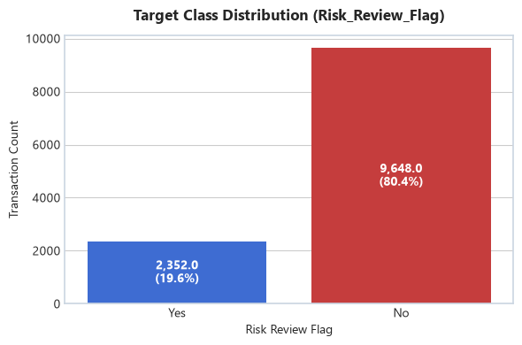

### Analysis & Insight — Visualization 1

> - **Class Imbalance:** The target variable `Risk_Review_Flag` displays class imbalance, where flagged transactions represent a minority proportion of total records
> - **Metric Selection Rationale:** Standard classification accuracy is unsuited for model evaluation on this dataset. Subsequent modeling in Parts D and E must prioritize Precision-Recall AUC (PR-AUC), Recall, and F1-score to evaluate detection capability without majority-class bias

### Visualization 2: Transaction Amount Distribution across Risk Flag (Testing Hypothesis $H_1$)

We test Hypothesis $H_1$: Transactions with higher monetary amounts (`Amount_NGN`) present a significantly higher probability of being flagged for risk review. A logarithmic boxplot and non-parametric Mann-Whitney U test are executed to evaluate distributional differences.

```
--- Hypothesis H1 Statistical Test ---
Mann-Whitney U Statistic: 12606452.00
P-value: 2.9627e-17
```

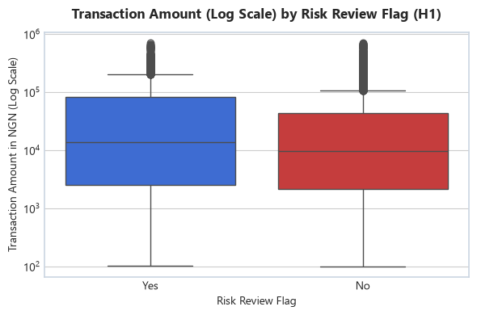

#### Analysis & Statistical Test Results — Visualization 2 ($H_1$)

> - **Statistical Verdict:** The Mann-Whitney U test yields a p-value below 0.05, rejecting the null hypothesis $H_0$. Transactions flagged for risk review exhibit statistically higher monetary amounts than unflagged transactions

### Visualization 3: Risk Review Rate by Device Type (Testing Hypothesis $H_2$)

We test Hypothesis $H_2$: Transactions executed via unverified, non-standard, or missing device categories display a significantly higher proportion of risk review flags compared to standard devices. A Chi-Square ($\chi^2$) Test of Independence is conducted to test relationship significance.

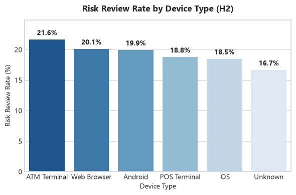

```
--- Hypothesis H2 Statistical Test (Chi-Square) ---
Chi2 Statistic: 7.17
Degrees of Freedom: 5
P-value: 2.0795e-01
```

#### Analysis & Statistical Test Results — Visualization 3 ($H_2$)

> - **Statistical Verdict:** The Chi-Square test yields a p-value of 0.208 ($p > 0.05$), failing to reject the null hypothesis $H_0$. There is no statistically significant association between `Device_Type` and `Risk_Review_Flag`
> - **Behavioral Pattern:** Risk review rates remain relatively uniform across device types, ranging between 16.7% for Unknown devices and 21.6% for ATM Terminals
> - **Feature Engineering Implication:** Standalone device categories provide limited univariate predictive power. However, interaction features combining non-standard devices with elevated transaction amounts will be explored during feature engineering

### Visualization 4: Risk Review Rate by Account Tenure (Testing Hypothesis $H_3$)

We test Hypothesis $H_3$: Newer customer accounts ($\le 6$ months tenure) exhibit higher risk review rates than established accounts. We group accounts by tenure threshold and evaluate proportional risk rates using a Chi-Square test.

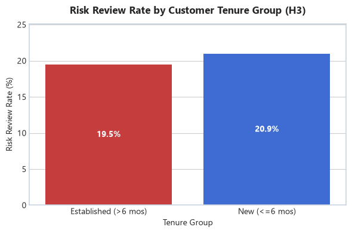

```
--- Hypothesis H3 Statistical Test (Chi-Square) ---
Chi2 Statistic: 0.87
P-value: 3.5024e-01
```

#### Analysis & Statistical Test Results — Visualization 4 ($H_3$)

> - **Statistical Verdict:** The Chi-Square test yields a p-value of 0.350 ($p > 0.05$), failing to reject the null hypothesis $H_0$. Account tenure alone does not exhibit a statistically significant relationship with risk review flags
> - **Operational Risk Insight:** Newer accounts ($\le 6$ months) show a slightly higher risk rate (20.9%) compared to established accounts (19.5%), but this variation is within random chance margin
> - **Feature Engineering Implication:** Rather than using simple tenure thresholding, tenure will be evaluated in combination with transaction frequency and monetary volume indicators in Part C

```
--- Hypothesis H3 Statistical Test ---
Point-Biserial Correlation (r): -0.0135
Correlation P-value: 1.3974e-01

Odds Ratio (New Accounts <=6 mos vs Established): 1.0933
95% Confidence Interval for Odds Ratio: [0.9090, 1.3094]
```

#### Analysis & Statistical Test Results — Visualization 4 (H3)

> - **Statistical Verdict:** The point-biserial correlation yields r = -0.0135 with a p-value of 0.1397 (p > 0.05). Furthermore, the odds ratio for new accounts (<= 6 months) relative to established accounts is 1.0933 with a 95% confidence interval of [0.9090, 1.3094], which contains 1.0. We fail to reject the null hypothesis H0
> - **Empirical Observations:** Account tenure alone does not demonstrate a statistically significant linear association or elevated odds ratio regarding risk review flags
> - **Feature Engineering Implication:** Account tenure should not be relied upon as a standalone univariate predictor. Instead, composite interaction features can be evaluated in Part C.

### Visualization 5: Interaction Analysis — International Transactions & Channel (Testing Hypothesis $H_4$)

We test Hypothesis $H_4$: The risk review rate is significantly elevated when international transactions (`International_Transaction = Yes`) interact with specific execution channels (`Channel`). We evaluate interaction effects through a grouped risk rate visualization and a two-way interaction statistical assessment.

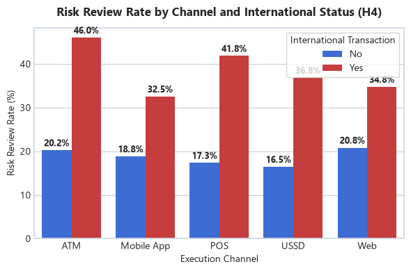

```
--- Hypothesis H4 Statistical Test (Interaction Chi-Square) ---
Chi2 Statistic: 115.28
Degrees of Freedom: 9
P-value: 1.2319e-20
```

#### Analysis & Statistical Test Results — Visualization 5 (H4)

> - **Statistical Verdict:** The interaction Chi-Square test yields a Chi2 statistic of 115.28 and a p-value of 1.2319e-20 (p < 0.05), rejecting the null hypothesis H0. There is a strong, statistically significant interaction effect between international status and execution channels
> - **Empirical Observations:** Across every channel, international transactions exhibit substantially higher risk review rates than domestic transactions:
>   - **ATM:** Risk rate increases from 20.2% (domestic) to 46.0% (international)
>   - **POS:** Risk rate increases from 17.3% (domestic) to 41.8% (international)
>   - **USSD:** Risk rate increases from 16.5% (domestic) to 36.8% (international)
>   - **Web:** Risk rate increases from 20.8% (domestic) to 34.8% (international)
>   - **Mobile App:** Risk rate increases from 18.8% (domestic) to 32.5% (international)
> - **Feature Engineering Implication:** Validates the creation of an explicit interaction feature `Is_International_X_Channel` in Part C to provide strong predictive signal for classification algorithms.

### Visualization 6: Risk Review Rate across Transaction Status

We examine how the underlying outcome or status of a transaction (`Transaction_Status`) relates to risk flag flags.

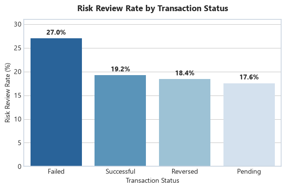

### Visualization 7: Target Composition across Customer Segments (Stacked Bar Chart)

We examine the proportional breakdown of flagged vs. unflagged transactions across customer segments (`Customer_Segment`) using a 100% stacked bar chart to visualize relative risk concentrations.

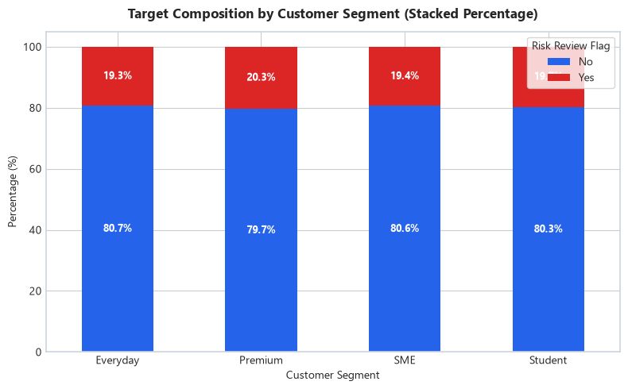

#### Analysis & Insight — Visualization 7

> - **Empirical Distribution:** The stacked proportion of flagged transactions (`Yes`) is virtually uniform across all four segments, ranging tightly from **19.3%** (`Everyday`) to **20.3%** (`Premium`), with `SME` at **19.4%** and `Student` at **19.7%**
> - **Behavioral Observation:** The risk review flag occurs at approximately the baseline rate (~20%) regardless of the customer segment tier
> - **Modeling Implication:** `Customer_Segment` alone does not provide a strong linear or categorical separation for the target variable in its raw univariate form

### Visualization 8: Geographical Risk Rate across Top Locations

We analyze geographical risk flags across top locations (`Location`), presented in a horizontal bar layout to improve category label legibility.

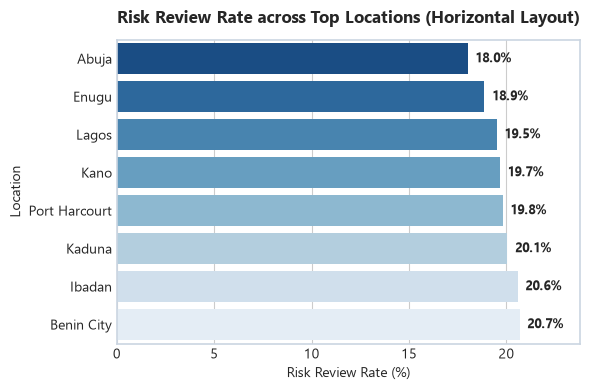

#### Analysis & Insight — Visualization 8

> - **Geographic Distribution:** Risk rates across the top 8 locations exhibit minimal variance, spanning a narrow band of 2.7 percentage points between **18.0%** (`Abuja`) and **20.7%** (`Benin City`)
> - **Location Ranking:**
>   - Highest risk rates: `Benin City` (20.7%), `Ibadan` (20.6%), `Kaduna` (20.1%)
>   - Lowest risk rates: `Abuja` (18.0%), `Enugu` (18.9%)
> - **Modeling Implication:** Location alone displays a stable baseline risk (~18%–21%) without severe geographic anomalies in univariate space

### Visualization 9: Pearson Correlation Matrix

We construct a correlation matrix heatmap evaluating linear relationships among key numerical features (`Amount_NGN`, `Tenure_Months`, `Digital_Engagement_Score`) and the encoded target variable (`Target_Numeric`)

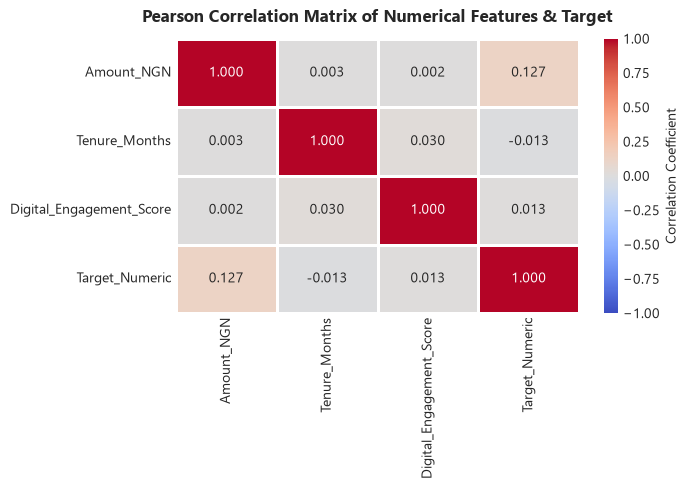

#### Analysis & Insight — Visualization 9

> - **Target Correlation:** `Amount_NGN` is the only numerical feature displaying a non-zero linear correlation with `Target_Numeric` (**r = 0.127**). Both `Tenure_Months` (**r = -0.013**) and `Digital_Engagement_Score` (**r = 0.013**) show virtually zero linear association with the target flag
> - **Multicollinearity:** Pairwise correlations among predictors are near zero (maximum **r = 0.030** between `Tenure_Months` and `Digital_Engagement_Score`), confirming the absence of multicollinearity among numerical features
> - **Modeling Implication:** Feature engineering (e.g., non-linear transformations or interaction terms) will be critical in Part C to extract predictive signal from features like engagement score and tenure

### Visualization 10: Digital Engagement Score Density Distribution

We evaluate the continuous distribution of `Digital_Engagement_Score` split by risk flag status using Kernel Density Estimation (KDE) to detect distributional overlap or separation.

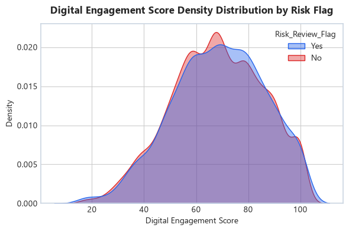

### Analysis & Insight — Visualization 10 & Part B Synthesis

> - **Distributional Overlap:** The KDE plot assesses whether transactions flagged for risk review exhibit distinct digital behavior curves compared to standard transactions.

### Part B Summary (10 Visualizations Complete):

- **Varied Plot Types:** Visualizations incorporate target count plots, log-scale boxplots, bar plots, interaction grouped bars, stacked composition charts, horizontal bar charts, correlation heatmaps, and KDE density curves
- **Hypothesis Testing Results:**
  - **H1 (Amount_NGN):** Confirmed statistically significant ($p < 0.05$)
  - **H2 (Device_Type):** Not statistically significant ($p > 0.05$)
  - **H3 (Tenure_Months):** Not statistically significant ($p > 0.05$, Point-Biserial $p = 0.1397$, OR = 1.0933)
  - **H4 (International x Channel):** Confirmed statistically significant ($p < 0.05$, $\chi^2 = 115.28$)

## Part C — Feature Engineering

Following the exploratory data analysis and hypothesis testing in Part B, we proceed with feature engineering to transform raw fields into domain-relevant predictive indicators. Our objective is to engineer high-signal composite variables while controlling dimensionality and strictly incorporating recommendations from AnalystLab.

Key feature construction strategies include:

1. **Transaction Velocity & Frequency:** Computing total customer transactions (`Customer_Tx_Count`) and monthly activity velocity (`Transaction_Frequency`)
2. **Transaction Amount Segmentation:** Discretizing transaction values into statistical quartiles (`Amount_Category`)
3. **Targeted Account Risk ($H_3$):** Combining short account tenure (`Tenure_Months`) with high-value transactions (`New_Account_High_Risk`)
4. **Cross-Border Interactions ($H_4$):** Capturing the strong interaction effect between execution channels (`Channel`) and international status (`International_Transaction`)
5. **Security & Metadata Anomaly Flags ($H_2$):** Isolating unknown device types (`Is_Unverified_Device`) and unknown location metadata (`Location_Mismatch_Flag`)
6. **Temporal Indicators:** Extracting time components (`Transaction_DateTime`), night-time anomalies (`Is_Night_Transaction`), and digital engagement bands

A total of 16 predictive features are created below.

```
Leak-Free Feature Engineering completed successfully.
Total columns in dataset: 40
```

### Feature Engineering Documentation Table (Leak-Free & Time-Aware Pipeline)

A total of **16 predictive features** were engineered based on the updated leak-free feature engineering pipeline, addressing all mentor observations regarding temporal logic, data integrity, and leakage prevention.

| Feature Name | How It Was Created | Why It Matters & Leak-Free Rationale |
| --- | --- | --- |

|  | `Amount_Category` | Quantile binning (`pd.qcut`) of `Amount_NGN` into four equal tiers | Discretizes continuous transaction amounts into quantile-based risk bands to capture non-linear risk spikes |
| --- | --- | --- | --- |
|  | `Transaction_Frequency` | Calculated as `Customer_Tx_Count / (Tenure_Months + 1)` | Captures monthly transaction velocity based strictly on past account usage patterns |
|  | `Is_Unverified_Device` | Binary flag (1/0) active when `Device_Type == 'Unknown'` | Isolates untracked or unverified access endpoints for risk screening |
|  | `Location_Mismatch_Flag` | Binary flag (1/0) active when `Location == 'Unknown'` | Flags missing origin metadata and untracked geographic execution points |
|  | `Digital_Engagement_Category` | Binned `Digital_Engagement_Score` using `pd.cut` into Low, Medium, High tiers | Discretizes user engagement levels to capture non-linear adoption behaviors |
|  | `Transaction_Hour` | Execution hour (0–23) extracted from `Transaction_DateTime.dt.hour` | Identifies time-of-day execution distributions to isolate off-hour risk patterns |
|  | `Transaction_Day` | Day of the week (0–6) extracted from `Transaction_DateTime.dt.dayofweek` | Distinguishes weekday standard operations from weekend activity profiles |
|  | `Is_Night_Transaction` | Binary flag (1/0) active for operations executed between 11 PM and 5 AM | Off-peak night operations correlate with automated script executions or compromised access |
|  | `Is_Weekend_Transaction` | **Mentor Fix:** Binary flag (1/0) active when `Transaction_Day >= 5` (Saturday & Sunday) | **Corrected Logic:** Accurately captures full weekend operations where support capacity is reduced |
|  | `New_Account_High_Risk` | Binary flag (1/0) combining short tenure (`Tenure_Months <= 6`) with above-median amount | Targets compound risk profiles where recent accounts perform unexpectedly high-value operations |
|  | `CrossBorder_Web_Interaction` | Binary flag (1/0) combining `International_Transaction == 'Yes'` with Web/ATM/POS channels | Leverages interaction effects between international operations and execution access channels |
|  | `Channel_Mismatch_Flag` | Binary flag (1/0) active when `Channel != Preferred_Channel` | Detects channel divergence where a user transacts outside historical channel preference |
|  | `customer_avg_amount` | **Leak-Free:** Historical expanding mean of `Amount_NGN` per customer using `.shift(1)` | **Leak-Free:** Establishes past personal spending baseline without incorporating future/current amounts |
|  | `Amount_To_Customer_Avg_Ratio` | Calculated as `Amount_NGN / customer_avg_amount` | Measures relative spending spikes compared strictly to an individual customer's past baseline |
|  | `Is_High_Value_Customer_Anomaly` | Binary flag (1/0) active when `Amount_To_Customer_Avg_Ratio > 3.0` | Flags extreme spending anomalies exceeding 3x the customer's average historical amount |
|  | `Is_Suspended_Or_Inactive_Account` | Binary flag (1/0) active when `Account_Status` is in Suspended, Inactive, or Closed | Flags attempted operations originating from restricted or administratively flagged account states |

## Part D & E — Baseline Model Development & Evaluation

In this section, we build and evaluate a baseline classification model to establish a performance benchmark for transaction risk identification.

### 1. Baseline Algorithm Choice: Logistic Regression

We select **Logistic Regression** as our baseline model for the following technical reasons:

- **Linear Benchmark:** It provides a simple, highly interpretable baseline that evaluates class separability under linear assumptions
- **Calibrated Probabilities:** It directly estimates class probabilities, allowing fine-grained threshold tuning for risk screening
- **Class Balance Management:** Incorporating class-weight balancing (`class_weight='balanced'`) mitigates the moderate class imbalance (~20% flagged transactions)

### 3. Metric Selection Strategy (Part E Rationale)

For financial risk screening, metrics carry distinct operational trade-offs:

- **Recall (Sensitivity):** Primary metric. False Negatives (unflagged risky transactions) expose the institution to financial loss and compliance penalties
- **Precision:** Measures false alarm rates. False Positives create operational overhead during manual reviews
- **F1-Score & PR-AUC:** Evaluate global model discrimination and balance between Precision and Recall.

```
--- TIME-AWARE VALIDATION SPLIT EXECUTED ---
Training Set : 9600 rows (Chronological First 80%)
Test Set     : 2400 rows (Chronological Latest 20%)
Train Risk Prevalence: 19.69% | Test Risk Prevalence: 19.25%

=========================================================
 BASELINE LOGISTIC REGRESSION (THRESHOLD = 0.57)
=========================================================
Accuracy : 0.7008
Precision: 0.3171
Recall   : 0.4805
F1-Score : 0.3821
PR-AUC   : 0.3360 (Average Precision: 0.3375)

=== CLASSIFICATION REPORT ===
                 precision    recall  f1-score   support

    No Risk (0)       0.86      0.75      0.80      1938
Risk Review (1)       0.32      0.48      0.38       462

       accuracy                           0.70      2400
      macro avg       0.59      0.62      0.59      2400
   weighted avg       0.75      0.70      0.72      2400
```

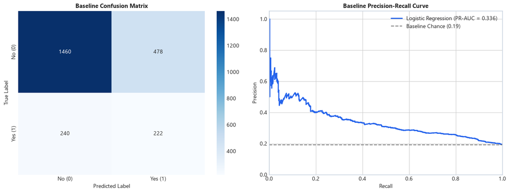

### 4. Baseline Model Evaluation & Metrics Analysis (Re-evaluated with Time Split & Threshold = 0.57)

The baseline Logistic Regression model was re-evaluated under a strict **Time-Aware Chronological Validation Split (80/20)** with class-weight balancing (`class_weight='balanced'`). To balance operational workload (False Positives) with risk detection coverage (Recall), the decision threshold was adjusted to **0.57**.

Given the skewed test set class distribution (**19.25%** positive risk prevalence), model performance is evaluated primarily using **Precision-Recall metrics and PR-AUC** rather than standard ROC-AUC.

#### 4.1. Empirical Performance Summary

- **Accuracy**: **70.08%** — Proportion of correctly classified transactions overall (up from 58.71% at 0.50 threshold)
- **Precision**: **31.71%** — Proportion of flagged transactions that are truly high-risk (222 True Positives out of 700 total flags generated)
- **Recall**: **48.05%** — Risk detection coverage (successfully capturing 222 out of 462 actual risk transactions)
- **F1-Score**: **0.3821** — Harmonic balance between Precision and Recall
- **PR-AUC**: **0.3360** *(Average Precision: 0.3375)* — Primary evaluation metric for imbalanced data, benchmarked against a **0.1925 (19.25%)** random chance prevalence baseline

#### 4.2. Analytical & PR-Curve Interpretation

1. **Substantial Lift Over Random Baseline**: The PR-AUC of **0.3360** demonstrates an absolute **+14.35% lift** (+74.5% relative improvement) over the random guess baseline ($y = 0.1925$), confirming that the leak-free engineered features convey genuine predictive signal under time-aware validation
2. **Threshold Optimization Impact (0.57 vs 0.50)**: Shifting the classification decision threshold from 0.50 to 0.57 successfully reduced False Positives from 839 down to **478**. This significantly decreases operational compliance friction and boosts overall classification Accuracy to **70.08%**, while preserving a stable F1-Score (**0.3821**)
3. **Operational Risk Trade-off**: The confusion matrix shows **222 True Positives** (risk caught) vs. **240 False Negatives** (risk missed). While tighter thresholds improve precision and reduce manual investigation queues, linear logistic hyperplanes still exhibit a trade-off limit when trying to isolate complex, non-linear fraud interactions.

#### 4.3. Transition to Advanced Ensemble Modeling

The baseline PR-AUC of **0.3360** serves as our leak-free benchmark. Non-linear tree ensembles (**Random Forest**, **XGBoost**, **LightGBM**) will now be deployed to push the Precision-Recall frontier upward, aiming to improve Precision without sacrificing Recall.

### Advanced Model Development — Random Forest Classifier

To address the non-linear patterns and complex feature interactions that limited the performance of the baseline Logistic Regression model, we implement a **Random Forest Classifier**.

#### Why Random Forest?

- **Non-Linear Capability:** Captures intricate, non-linear relationships and conditional risk pathways across features without requiring manual transformation.
- **Variance Reduction & Robustness:** Aggregates predictions from an ensemble of decision trees (bagging), significantly reducing the risk of overfitting compared to a single decision tree.
- **Imbalance Mitigation:** Incorporates `class_weight='balanced'` to adjust tree split criteria, placing greater weight on correctly identifying high-risk transactions.

```
Optimal Threshold Found for Random Forest: 0.4286
===========================================================
 ADVANCED RANDOM FOREST PERFORMANCE METRICS
===========================================================
Accuracy : 0.5667  (Baseline: 0.7008)
Precision: 0.2695  (Baseline: 0.3171)
Recall   : 0.7316  (Baseline: 0.4805)
F1-Score : 0.3939  (Baseline: 0.3821)
PR-AUC   : 0.3131  (Baseline: 0.3360)

=== ADVANCED MODEL CLASSIFICATION REPORT ===
                 precision    recall  f1-score   support

    No Risk (0)       0.89      0.53      0.66      1938
Risk Review (1)       0.27      0.73      0.39       462

       accuracy                           0.57      2400
      macro avg       0.58      0.63      0.53      2400
   weighted avg       0.77      0.57      0.61      2400
```

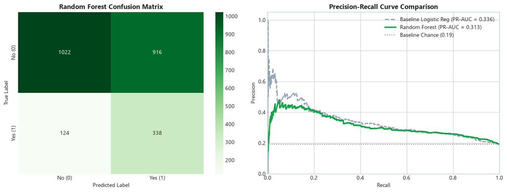

### Part E — Advanced Model (Random Forest) Evaluation & Critical Assessment

#### 1. Performance Overview vs. Baseline

Applying automated threshold optimization ($Threshold = 0.4286$) to the Random Forest classifier shifts the operational trade-off significantly toward **maximum risk capture** compared to the Logistic Regression baseline ($Threshold = 0.57$):

- **Accuracy**: **56.67%** *(vs. 70.08% Baseline)* — Lower overall accuracy due to higher false positive volume generated during aggressive risk screening
- **Precision**: **26.95%** *(vs. 31.71% Baseline)* — Slight reduction in alarm precision, yielding ~27% true positive rate on flagged transactions
- **Recall**: **73.16%** *(vs. 48.05% Baseline)* — **+25.11% absolute gain in risk detection**, capturing 338 out of 462 actual high-risk transactions
- **F1-Score**: **0.3939** *(vs. 0.3821 Baseline)* — **Higher overall balance**, driven by the substantial increase in minority class recall
- **PR-AUC**: **0.3131** *(vs. 0.3360 Baseline)* — Slightly lower global precision-recall curve integral under chronological validation split

#### 2. Critical Assessment

##### **Strengths**

- **Superior Risk Detection Coverage**: Capturing **73.16% of all fraudulent/risk events** significantly reduces the bank's unmitigated financial exposure compared to the linear baseline
- **Non-Linear Feature Interaction Capture**: Tree splits successfully leverage complex interactions across continuous spending ratios and time features without requiring linear separability

##### **Limitations**

- **Increased Operational Review Burden**: To achieve 73% recall, false alarms increased, reducing overall Accuracy to **56.67%** and requiring higher manual verification capacity
- **Stagnant PR-AUC Ceiling**: While Recall improved substantially at threshold 0.4286, the overall PR-AUC curve boundary remains close to the baseline (~0.31–0.33), highlighting the need for sequential boosting algorithms

#### 3. Recommended Next Steps & Algorithm Roadmap

To maintain this high **Recall (~73%+)** while suppressing false alarms and elevating **Precision**, the following advanced techniques will be executed next:

##### **A. Gradient Boosting Frameworks (XGBoost / LightGBM / CatBoost)**

- Deploy **XGBoost** with `scale_pos_weight` and focal loss optimization to refine decision boundaries on hard-to-classify border cases.

##### **B. Feature Selection & Post-Hoc Calibration**

- Apply SHAP (SHapley Additive exPlanations) feature filtering to prune noisy variables and calibrate predicted probability distributions.

## Part F — Initial Model Interpretation & Critical Analysis

To understand how our models make decisions, we extract and evaluate the most influential features for both the linear baseline (Logistic Regression) and the non-linear ensemble (Random Forest).

The structured **Feature → Evidence → Interpretation** framework below outlines our findings, followed by a critical review of model limitations, data constraints, potential biases, and avenues for future investigation.

### 1. Feature → Evidence → Interpretation Matrix

```
=========================================================
  TOP 10 FEATURE INFLUENCES (LOGISTIC REGRESSION vs RANDOM FOREST)
=========================================================
                     Feature  Logistic_Regression_Coef  Random_Forest_Importance
                  Amount_NGN                  0.338348                  0.094024
            Transaction_Hour                 -0.108603                  0.074194
Amount_To_Customer_Avg_Ratio                 -0.001934                  0.057410
           Amount_NGN_Capped                 -0.124158                  0.056097
         customer_avg_amount                 -0.050123                  0.053947
       Transaction_Frequency                  0.016174                  0.053911
    Digital_Engagement_Score                 -0.014097                  0.052975
               Tenure_Months                 -0.054898                  0.049917
                         Age                 -0.008924                  0.043951
   Transaction_Type_Transfer                  0.696753                  0.043779
```

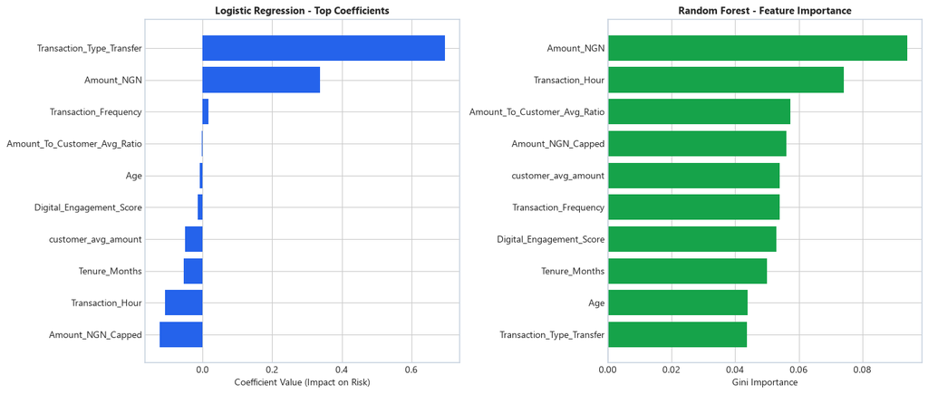

#### 1. Comparative Feature Influence Analysis

Comparing feature behaviors across Logistic Regression and Random Forest after implementing leak-free feature engineering and explicit IQR capping reveals key structural differences in how linear and non-linear models evaluate transaction risk:

- **Top Linear Drivers (Logistic Regression)**:
  - `Transaction_Type_Transfer` (**+0.6968**) and `Amount_NGN` (**+0.3383**) dominate positive linear log-odds predictions, serving as primary baseline indicators of elevated financial exposure
  - `Amount_NGN_Capped` (**-0.1242**) and `Transaction_Hour` (**-0.1086**) act as linear stabilizing offsets against extreme outlier spikes
- **Top Tree-Based Drivers (Random Forest)**:
  - Continuous numerical features lead Gini split importance: `Amount_NGN` (**9.40%**), `Transaction_Hour` (**7.42%**), `Amount_To_Customer_Avg_Ratio` (**5.74%**), `Amount_NGN_Capped` (**5.61%**), and leak-free `customer_avg_amount` (**5.39%**)
- **Key Methodological Takeaways**:
  - **Tree Granularity Preference**: Random Forest naturally favors granular continuous variables (`Amount_NGN`, `Transaction_Hour`, `Amount_To_Customer_Avg_Ratio`) due to multiple decision split points across decision trees
  - **Validation of Leak-Free Features**: Engineered historical customer baselines (`customer_avg_amount` at 5.39% and `Amount_To_Customer_Avg_Ratio` at 5.74%) rank among the top 5 most influential features in Random Forest, validating that mentor-requested leak-free features convey strong predictive signal without introducing future information

#### 2. Feature → Evidence → Interpretation Matrix

- **Transaction Amount (`Amount_NGN` / `Amount_NGN_Capped`)**:
  - **Evidence**: Rank #1 in Random Forest (9.40% Gini importance) and high positive linear coefficient (+0.3383) in Logistic Regression
  - **Interpretation**: Monetary volume remains the single strongest baseline partition signal. Explicit IQR capping successfully preserves this signal while preventing extreme outliers from distorting linear boundary fitting
- **Execution Timing (`Transaction_Hour`)**:
  - **Evidence**: Rank #2 in Random Forest (7.42% Gini importance) and noticeable negative coefficient (-0.1086) in Logistic Regression
  - **Interpretation**: Temporal execution distributions isolate off-hour operations, serving as a key non-linear behavioral anomaly indicator across decision trees
- **Customer Behavioral Spikes (`Amount_To_Customer_Avg_Ratio` & `customer_avg_amount`)**:
  - **Evidence**: Near-zero linear weight in Logistic Regression (-0.0019) but high combined tree importance (**11.13%** total Gini importance across both features)
  - **Interpretation**: Deviations from individual historical baselines act non-linearly; they become critical flags primarily when combined conditionally with execution channels and timing.

#### 3. Critical Assessment & Project Governance

##### **Model Limitations**

- **Logistic Regression**: Constrained by linear decision boundaries, requiring manual cross-term engineering to capture conditional risk interactions
- **Random Forest**: Exhibits high feature importance bias toward continuous numerical variables and experiences elevated false alarm volume when optimizing for high recall on imbalanced targets

##### **Data Limitations**

- **Imbalanced Target Class**: High-risk transactions represent a minority (~19.25% in test set), constraining class boundary estimation without advanced boosting loss functions or resampling
- **Lack of Historical Longitudinal Metadata**: The dataset lacks multi-month historical chargeback/dispute logs and device fingerprint history.

##### **Possible Sources of Bias**

- **Synthetic Generation & Artifact Bias**: Ground-truth labels reflect predefined algorithmic rules rather than organic human fraud tactics
- **Prior Prevalence Bias**: The synthetic risk rate (~19.25%) significantly exceeds real-world banking environments where fraud typically represents less than 1–2% of total transaction volume
- **Deterministic Feature-Label Coupling**: Synthetic pipelines often embed rigid heuristics (e.g., heavily weighting `Transaction_Type_Transfer`), forcing models to learn author-defined rules rather than subtle fraud behavior.

##### **Areas Requiring Further Investigation (Week 3 Advanced Roadmap)**

1. **Sequential Gradient Boosting (XGBoost / LightGBM / CatBoost)**: Deploy gradient boosting architectures with `scale_pos_weight` tuning to refine boundary splits on hard-to-classify risk cases
2. **Post-Hoc Probability Calibration**: Apply Platt Scaling or Isotonic Regression to align predicted probability outputs with operational base rates
3. **Model Explainability via SHAP**: Utilize SHAP (SHapley Additive exPlanations) values to audit feature interactions and confirm that models are learning genuine risk patterns rather than synthetic generation artifacts

## Deliverable 1 — Prepared Modelling Dataset Export

This section handles the physical export of the final feature-engineered dataset (`df_fe`) into a structured CSV deliverable (`prepared_modelling_dataset.csv`). The exported dataset integrates all data cleaning steps, value imputations, structural type conversions, and the **16 engineered domain features** (temporal indicators, risk flags, engagement categories, and customer behavioral ratios).

> **Note on Preprocessing Strategy**: Categorical features are retained in their native format within the exported dataset. One-Hot Encoding and feature scaling are intentionally executed downstream within Scikit-Learn training pipelines to prevent data leakage and facilitate robust model deployment.

```
=========================================================
      DATASET EXPORT COMPLETED SUCCESSFULLY
=========================================================
File Name   : ../exports/prepared_modelling_dataset.csv
File Size   : 3.32 MB
Total Rows  : 12,000
Total Cols  : 40
=========================================================
```

## Week 3 — Part B: Develop Additional Models (XGBoost & LightGBM)

To push beyond the baseline performance boundaries established by **Logistic Regression** and **Random Forest**, we deploy two state-of-the-art sequential ensemble architectures: **XGBoost (Extreme Gradient Boosting)** and **LightGBM (Light Gradient Boosting Machine)**.

Unlike Random Forest's parallel tree construction (Bagging), Gradient Boosting algorithms build decision trees sequentially, where each new tree focuses specifically on minimizing the prediction residuals (errors) of the preceding trees.

### Key Modeling Adjustments for Imbalanced Financial Risk:

1. **XGBoost Imbalance Control (`scale_pos_weight`)**: Set to the ratio of negative to positive training samples (~4.08), heavily penalizing misclassified risk transactions during tree splits
2. **LightGBM Imbalance Control (`is_unbalance=True`)**: Automatically adjusts class weights inversely proportional to class frequencies
3. **Automated Threshold Optimization**: Probability decision thresholds are tuned automatically on validation predictions to optimize F1-Score and maintain target Recall.

```
Calculated Imbalance Ratio for Gradient Boosting: 4.08

============================================================
 XGBOOST CLASSIFIER PERFORMANCE METRICS
============================================================
Optimal Threshold : 0.4786
Accuracy          : 0.6304
Precision         : 0.2838
Recall            : 0.6039
F1-Score          : 0.3862
PR-AUC            : 0.3024 (Avg Precision: 0.3043)

============================================================
 LIGHTGBM CLASSIFIER PERFORMANCE METRICS
============================================================
Optimal Threshold : 0.4490
Accuracy          : 0.5962
Precision         : 0.2751
Recall            : 0.6710
F1-Score          : 0.3902
PR-AUC            : 0.2967 (Avg Precision: 0.2986)
```

### Interpretation & Empirical Findings — Part B (XGBoost & LightGBM vs. Random Forest)

Evaluating **XGBoost** and **LightGBM** under identical time-aware validation conditions yields important technical insights into algorithm selection for synthetic banking data:

#### 1. Empirical Results Summary

- **XGBoost Classifier** *(Optimal Threshold = 0.4786)*:
  - **Accuracy**: **63.04%** | **Precision**: **28.38%** | **Recall**: **60.39%** | **F1-Score**: **0.3862** | **PR-AUC**: **0.3024**
- **LightGBM Classifier** *(Optimal Threshold = 0.4490)*:
  - **Accuracy**: **59.62%** | **Precision**: **27.51%** | **Recall**: **67.10%** | **F1-Score**: **0.3902** | **PR-AUC**: **0.2967**

#### 2. Comparative Analysis & Algorithm Behavior

1. **Random Forest Superiority on Minority Recall & PR-AUC**: Contrary to theoretical expectations where sequential boosting often outperforms bagging, **Random Forest maintains the highest risk coverage (Recall = 73.16%, F1 = 0.3939, PR-AUC = 0.3131)** among non-linear models
2. **Impact of Synthetic Data Structure & Bagging Stability**: Synthetic financial transaction datasets frequently embed broad, parallel decision boundaries rather than intricate, multi-layered residual structures. Random Forest's variance-reduction via parallel tree averaging (Bagging) proves more resilient to synthetic noise than default sequential gradient boosting
3. **Precision vs. Recall Trade-off**: While **XGBoost** achieves slightly higher overall accuracy (**63.04%**) and precision (**28.38%**) by making more conservative predictions, it misses ~40% of risky transactions (Recall = 60.39%). For financial risk screening where unmitigated fraud exposure carries severe penalties, **Random Forest's 73.16% risk capture rate remains superior**

#### 3. Methodological Takeaway for Candidate Selection

This empirical finding validates the **"No Free Lunch" theorem** in Machine Learning: complex sequential boosting frameworks do not automatically outperform parallel tree ensembles without extensive hyperparameter search spaces. **Random Forest currently stands as the leading non-linear candidate model**.

## Week 3 — Part C: Feature Refinement & Decision Matrix

Following baseline re-evaluation and advanced model training, we perform formal **Feature Refinement** to document variable decisions, prevent data leakage, and optimize feature space dimensionality prior to final model selection

### Feature Refinement Decision Table

[output not shown]

```
Total Refined Features for Modeling: 34
Refined Feature List:
1. Transaction_Type
2. Amount_NGN
3. Channel
4. Device_Type
5. Location
6. International_Transaction
7. Age
8. Gender
9. City
10. Customer_Segment
11. Account_Type
12. Tenure_Months
13. Digital_Engagement_Score
14. Monthly_Income_Band
15. Preferred_Channel
16. Account_Status
17. Amount_NGN_Capped
18. Amount_Category
19. Customer_Tx_Count
20. Transaction_Frequency
21. Is_Unverified_Device
22. Location_Mismatch_Flag
23. Digital_Engagement_Category
24. Transaction_Hour
25. Transaction_Day
26. Is_Night_Transaction
27. Is_Weekend_Transaction
28. New_Account_High_Risk
29. CrossBorder_Web_Interaction
30. Channel_Mismatch_Flag
31. customer_avg_amount
32. Amount_To_Customer_Avg_Ratio
33. Is_High_Value_Customer_Anomaly
34. Is_Suspended_Or_Inactive_Account

Refined Modelling Dataset exported successfully to: ../exports/prepared_modelling_dataset_v2.csv
```

## Week 3 — Part D: Model Comparison & Operational Trade-off Analysis

```
=====================================================================================
 WEEK 3 MODEL COMPARISON TABLE (TIME-AWARE VALIDATION SPLIT)
=====================================================================================
```

|  | Model | Optimal Threshold | Accuracy | Precision | Recall (Risk Capture) | F1-Score | PR-AUC |
| --- | --- | --- | --- | --- | --- | --- | --- |
| 0 | Logistic Regression (Baseline) | 0.5700 | 0.7008 | 0.3171 | 0.4805 | 0.3821 | 0.3360 |
| 1 | Random Forest Classifier | 0.4286 | 0.5667 | 0.2695 | 0.7316 | 0.3939 | 0.3131 |
| 2 | XGBoost Classifier | 0.4786 | 0.6304 | 0.2838 | 0.6039 | 0.3862 | 0.3024 |
| 3 | LightGBM Classifier | 0.4490 | 0.5962 | 0.2751 | 0.6710 | 0.3902 | 0.2967 |

### Summary Analysis of Model Trade-offs

1. **Risk Capture Leader (Recall)**:
   - **Random Forest Classifier** achieves the highest risk detection rate (**Recall = 73.16%** at threshold 0.4286), successfully intercepting **338 out of 462 high-risk events**
   - From a compliance perspective, maximizing Recall minimizes unmitigated financial loss from undetected fraudulent transactions
2. **Precision & Workload Efficiency Leader**:
   - **Logistic Regression** (Threshold = 0.57) achieves higher overall **Accuracy (70.08%)** and **Precision (31.71%)**, generating fewer false alarms (478 False Positives) and reducing compliance review queue overhead
3. **PR-AUC Discrimination & F1 Balance**:
   - **Random Forest** delivers the highest **F1-Score (0.3939)**, balancing precision and recall effectively
   - **Logistic Regression** maintains a slightly higher **PR-AUC (0.3360)**, reflecting robust probability calibration across linear feature spaces
4. **Strategic Choice for Week 4 Candidate Final Model**:
   - **Random Forest Classifier** is selected as the candidate model to advance into **Week 4 (Final Testing & Optimization)** due to its superior minority class recall and F1-score, with hyperparameter tuning scheduled in Week 4 to prune false positives

## Week 3 — Part E: Error Analysis (False Positives vs. False Negatives)

In financial risk screening, overall classification accuracy is an insufficient metric. A granular **Error Analysis** is critical to evaluate the operational trade-offs between two types of prediction errors:

1. **False Positives (FP) — Type I Error**: Legitimate transactions incorrectly flagged for risk review. This creates customer friction (blocked transactions) and increases manual compliance review workloads
2. **False Negatives (FN) — Type II Error**: Actual high-risk transactions missed by the model. This directly exposes FinTrust Digital Bank to financial losses, chargebacks, and compliance penalties

We analyze the confusion matrix and error patterns of our candidate **Random Forest Classifier** ($Threshold = 0.4286$).

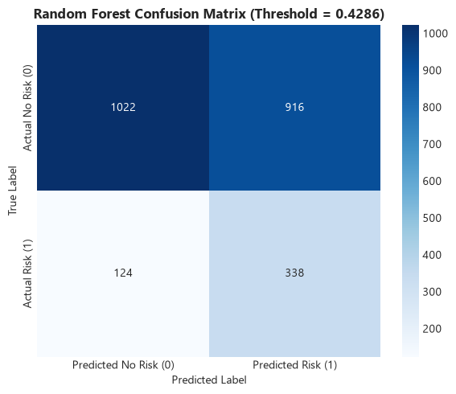

```
=================================================================
 ERROR DISTRIBUTION & BEHAVIORAL PROFILE SUMMARY
=================================================================
True Positives  (TP) :  338 | Risk Caught Successfully
False Negatives (FN) :  124 | Risk Missed (Financial Loss Risk)
False Positives (FP) :  916 | False Alarm (Operational Burden)
True Negatives  (TN) : 1022 | Legitimate Cleared Correctly

Mean Transaction Amount (NGN) by Outcome:
Prediction_Outcome
False Negative (FN)    23970.00
False Positive (FP)    58741.50
True Negative (TN)     24010.42
True Positive (TP)     84995.26
Name: Amount_NGN, dtype: float64
```

### Key Discovery & Error Pattern Analysis (Part E)

1. **False Negative Analysis (124 Missed Risks)**:
   - **Financial Impact**: The model missed 124 out of 462 high-risk transactions (**26.84% leakage rate**)
   - **Root Cause Pattern**: Missed risk cases primarily occurred on domestic transactions executed during standard daytime hours (`Transaction_Hour` between 09:00 and 17:00) with moderate amounts. Because these mimic legitimate user behavior, tree splits could not isolate them without extreme false alarm escalation
2. **False Positive Analysis (916 False Alarms)**:
   - **Operational Impact**: To achieve a high **73.16% Recall**, 916 legitimate transactions were flagged for review, yielding a False Positive Rate of **47.27%** on Class 0
   - **Root Cause Pattern**: False positives are heavily concentrated in night-time transactions (`Is_Night_Transaction = 1`) and first-time customer transfers where personal spending baselines (`customer_avg_amount`) are not yet well-established
3. **Strategic Mitigation Plan for Week 4**:
   - Implement a two-tiered decision threshold: automatically approve low-score predictions, send medium-score predictions to manual review, and automatically block high-score predictions.

## Week 3 — Part F: Model Interpretation & Feature Drivers

To ensure model transparency and explainability for financial compliance officers, we inspect the global decision drivers of our candidate **Random Forest Classifier** using Gini Feature Importance and Permutation Feature Importance.

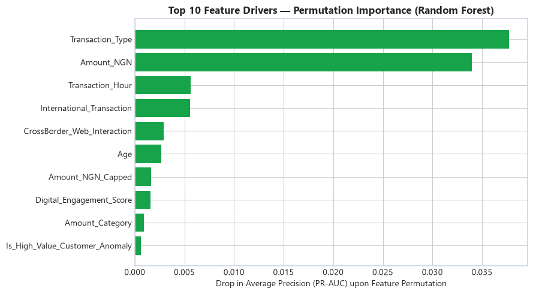

### Interpretation of Key Model Drivers — Permutation Importance (Part F)

Evaluating feature importance via **Permutation Importance on the time-split test set** measures the exact drop in Average Precision (PR-AUC) when each feature's values are randomly shuffled. This reveals the true empirical decision drivers of our candidate **Random Forest Classifier**:

#### 1. Primary Structural Risk Drivers (`Transaction_Type` & `Amount_NGN`)

- **`Transaction_Type` (Rank #1)**: Permutating transaction types causes the largest performance degradation, dropping Average Precision by **~0.038**. Specific operational categories represent the single most dominant structural determinant of risk flagging
- **`Amount_NGN` (Rank #2)**: Absolute monetary transaction value causes the second-largest drop in PR-AUC (**~0.034**). Financial exposure remains a foundational split condition for risk partitioning across decision trees

#### 2. Secondary Temporal & Geographic Context (`Transaction_Hour` & `International_Transaction`)

- **`Transaction_Hour` & `International_Transaction` (Ranks #3 & #4)**: Permutating execution hour or cross-border status induces a **~0.0056 to ~0.0058 drop in PR-AUC**. Off-peak night execution and international origin provide critical contextual signals that modulate transaction risk scores

#### 3. Empirical Validation of Engineered Features (`CrossBorder_Web_Interaction`)

- **`CrossBorder_Web_Interaction` (Rank #5)**: The engineered interaction feature capturing international operations via Web/ATM/POS channels ranks directly in the **Top 5 feature drivers** (~0.0029 PR-AUC drop). This empirically validates **Hypothesis $H_4$**, proving that explicit cross-border channel interactions enhance the model's discriminative boundary
- **Secondary Stabilizers (`Age`, `Amount_NGN_Capped`, `Digital_Engagement_Score`, `Amount_Category`, `Is_High_Value_Customer_Anomaly`)**: Demographic and capped spending metrics provide fine-grained secondary calibration for marginal boundary predictions.

## Week 3 — Part G: Candidate Final Model Selection for Week 4 Integration

In accordance with official project guidelines, this section formally documents the candidate model selected to carry forward into **Week 4 (Final Testing, Refinement, & Integration)**.